# Notes_L4

Paolo Crosetto

10/8/2021

## L4

### intro à RmD

je veux du texte

```r
print("je veux du code")
```

```
## [1] "je veux du code"
```

## 1. Join

exercices de join sur les données de `flights`, `planes` et `airports`.

```r
library(tidyverse)
library(nycflights13)


# assign each dataset to a local object
fl <- flights
ai <- airports
pl <- planes
```

Les élements qu’on veut sont repartis sur 3 bases de données différentes.

Ils faut les joindre!

#### 1. controler que les clés sont uniques

Est-ce que le nombre de gourpes est égal au nombre d’observation?

```r
pl %>% group_by(tailnum)
```

```
## # A tibble: 3,322 x 9
## # Groups:   tailnum [3,322]
##    tailnum  year type          manufacturer   model  engines seats speed engine
##    <chr>   <int> <chr>         <chr>          <chr>    <int> <int> <int> <chr>
##  1 N10156   2004 Fixed wing m~ EMBRAER        EMB-1~       2    55    NA Turbo-~
##  2 N102UW   1998 Fixed wing m~ AIRBUS INDUST~ A320-~       2   182    NA Turbo-~
##  3 N103US   1999 Fixed wing m~ AIRBUS INDUST~ A320-~       2   182    NA Turbo-~
##  4 N104UW   1999 Fixed wing m~ AIRBUS INDUST~ A320-~       2   182    NA Turbo-~
##  5 N10575   2002 Fixed wing m~ EMBRAER        EMB-1~       2    55    NA Turbo-~
##  6 N105UW   1999 Fixed wing m~ AIRBUS INDUST~ A320-~       2   182    NA Turbo-~
##  7 N107US   1999 Fixed wing m~ AIRBUS INDUST~ A320-~       2   182    NA Turbo-~
##  8 N108UW   1999 Fixed wing m~ AIRBUS INDUST~ A320-~       2   182    NA Turbo-~
##  9 N109UW   1999 Fixed wing m~ AIRBUS INDUST~ A320-~       2   182    NA Turbo-~
## 10 N110UW   1999 Fixed wing m~ AIRBUS INDUST~ A320-~       2   182    NA Turbo-~
## # ... with 3,312 more rows
```

est-ce qu’il y a un groupe avec plus d’un membre ?

```r
pl %>% group_by(tailnum) %>%  filter(n()>1)
```

```
## # A tibble: 0 x 9
## # Groups:   tailnum [0]
## # ... with 9 variables: tailnum <chr>, year <int>, type <chr>,
## #   manufacturer <chr>, model <chr>, engines <int>, seats <int>, speed <int>,
## #   engine <chr>
```

### do newer planes fly longest routes?

- chercher l’age des avions dans “planes”
- utiliser `left_join`
- la base de référence est `flights` et la base où on cherche l’info additionnelle est `planes`

```r
question1 <-fl %>%
  rename(year_flight = year) %>%
  left_join(pl, by = "tailnum")
```

On va donc pouvoir répondre à la question

Autrement dit, y a-t-il une corrélation entre year de production de l’avion et distance parcourue?

Solution 1: stat des plus plot

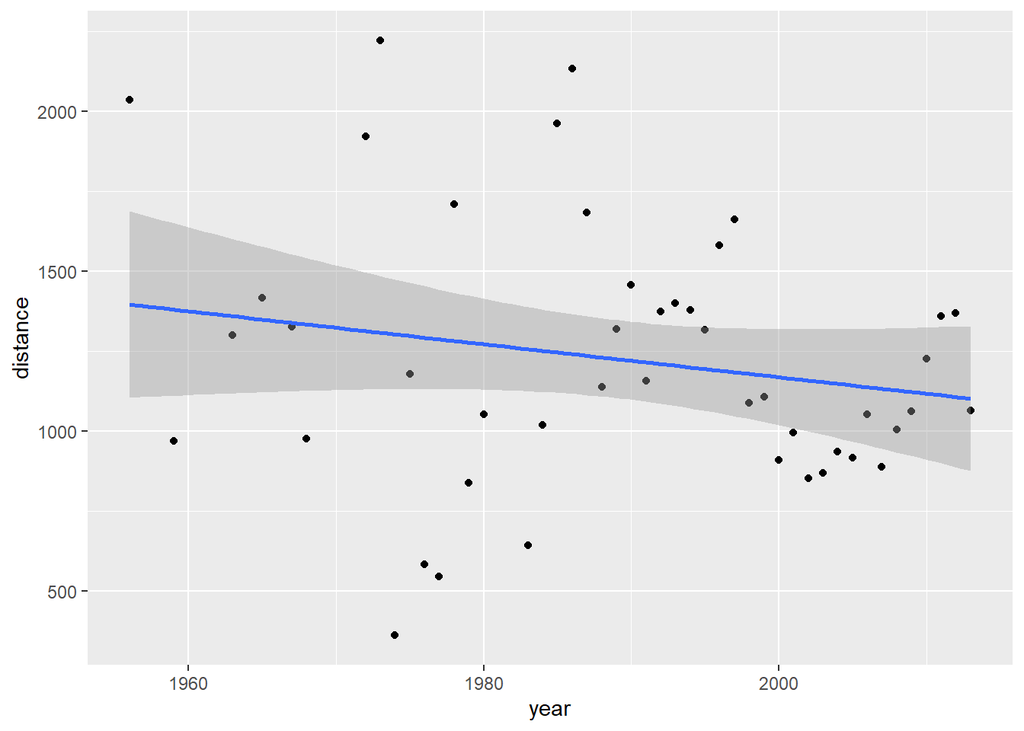

```r
## stat des + plot
question1 %>%
  group_by(year) %>%
  summarise(distance = mean(distance, na.rm = T)) %>%
  ggplot()+
  aes(year, distance)+
  geom_point()+
  geom_smooth(method = "lm")
```

Solution 2: juste plot

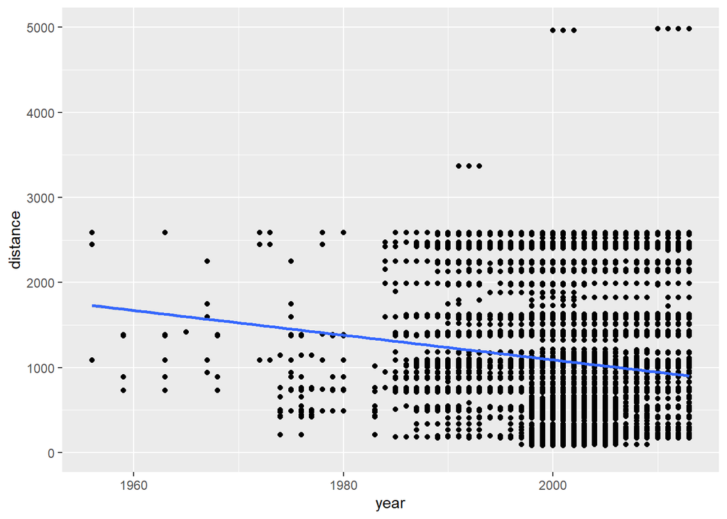

```r
question1 %>%
  ggplot() +
  aes(year, distance) +
  geom_point() +
  geom_smooth(method = "lm")
```

Solution 3: regression

```r
question1 %>%
  lm(distance~year, data = .) %>%
  broom::tidy()
```

```
## # A tibble: 2 x 5
##   term        estimate std.error statistic p.value
##   <chr>          <dbl>     <dbl>     <dbl>   <dbl>
## 1 (Intercept)  30111.    448.         67.2       0
## 2 year           -14.5     0.224     -64.8       0
```

### exo 2: destination airports > 1000 m on the sea level

1. check uniqueness

```r
ai %>%  group_by(faa)
```

```
## # A tibble: 1,458 x 8
## # Groups:   faa [1,458]
##    faa   name                             lat    lon   alt    tz dst   tzone
##    <chr> <chr>                          <dbl>  <dbl> <dbl> <dbl> <chr> <chr>
##  1 04G   Lansdowne Airport               41.1  -80.6  1044    -5 A     America/~
##  2 06A   Moton Field Municipal Airport   32.5  -85.7   264    -6 A     America/~
##  3 06C   Schaumburg Regional             42.0  -88.1   801    -6 A     America/~
##  4 06N   Randall Airport                 41.4  -74.4   523    -5 A     America/~
##  5 09J   Jekyll Island Airport           31.1  -81.4    11    -5 A     America/~
##  6 0A9   Elizabethton Municipal Airport  36.4  -82.2  1593    -5 A     America/~
##  7 0G6   Williams County Airport         41.5  -84.5   730    -5 A     America/~
##  8 0G7   Finger Lakes Regional Airport   42.9  -76.8   492    -5 A     America/~
##  9 0P2   Shoestring Aviation Airfield    39.8  -76.6  1000    -5 U     America/~
## 10 0S9   Jefferson County Intl           48.1 -123.    108    -8 A     America/~
## # ... with 1,448 more rows
```

2. join

Attention! la variable a deux noms différents!!!

elle s’appelle `dest` dans `flights` et elle s’appelle `faa` dans `airports`

```r
question2 <- fl %>%
  left_join(ai, by = c("dest" = "faa"))
```

3. répondre à la question
4. calculer la variable altitude en mètres
5. filtrer les dest > 1000m s.n.m.

```r
question2 %>%
  mutate(alt_m = alt/3.28084) %>%
  filter(alt_m > 1000)
```

```
## # A tibble: 10,291 x 27
##     year month   day dep_time sched_dep_time dep_delay arr_time sched_arr_time
##    <int> <int> <int>    <int>          <int>     <dbl>    <int>          <int>
##  1  2013     1     1      646            645         1      910            916
##  2  2013     1     1      655            655         0     1021           1030
##  3  2013     1     1      727            730        -3      959            952
##  4  2013     1     1      752            750         2     1025           1029
##  5  2013     1     1      754            755        -1     1103           1030
##  6  2013     1     1      813            815        -2     1103           1056
##  7  2013     1     1      833            835        -2     1134           1102
##  8  2013     1     1      848            851        -3     1155           1136
##  9  2013     1     1      906            843        23     1134           1125
## 10  2013     1     1      926            928        -2     1233           1220
## # ... with 10,281 more rows, and 19 more variables: arr_delay <dbl>,
## #   carrier <chr>, flight <int>, tailnum <chr>, origin <chr>, dest <chr>,
## #   air_time <dbl>, distance <dbl>, hour <dbl>, minute <dbl>, time_hour <dttm>,
## #   name <chr>, lat <dbl>, lon <dbl>, alt <dbl>, tz <dbl>, dst <chr>,
## #   tzone <chr>, alt_m <dbl>
```

### exercice 3: joining 3 datasets!!

il faut toujours faire le join 2 à la fois!

question: age moyen des avions qui volent à des destinations >1000m?

- vols c’est dans flights
- age avions c’est dans planes
- altitude destination c’est dans airports

```r
question3 <- fl %>%
  left_join(ai, by = c("dest" = "faa")) %>%
  rename(year_flight = year) %>%
  left_join(pl, by = "tailnum")
```

réponse

```r
question3 %>%
  mutate(alt_m = alt/3.28084) %>%
  filter(alt_m > 1000) %>%
  summarise(answer = mean(year, na.rm = T))
```

```
## # A tibble: 1 x 1
##   answer
##    <dbl>
## 1  2000.
```

# Partie 2: tidy data

## 1. pivot_longer

```r
table4a
```

```
## # A tibble: 3 x 3
##   country     `1999` `2000`
## * <chr>        <int>  <int>
## 1 Afghanistan    745   2666
## 2 Brazil       37737  80488
## 3 China       212258 213766
```

pivot longer

```r
table4a %>%
  pivot_longer(cols = -country, names_to = "année", values_to = "cas")
```

```
## # A tibble: 6 x 3
##   country     année    cas
##   <chr>       <chr>  <int>
## 1 Afghanistan 1999     745
## 2 Afghanistan 2000    2666
## 3 Brazil      1999   37737
## 4 Brazil      2000   80488
## 5 China       1999  212258
## 6 China       2000  213766
```

## 2. pivot_wider

```r
table2
```

```
## # A tibble: 12 x 4
##    country      year type            count
##    <chr>       <int> <chr>           <int>
##  1 Afghanistan  1999 cases             745
##  2 Afghanistan  1999 population   19987071
##  3 Afghanistan  2000 cases            2666
##  4 Afghanistan  2000 population   20595360
##  5 Brazil       1999 cases           37737
##  6 Brazil       1999 population  172006362
##  7 Brazil       2000 cases           80488
##  8 Brazil       2000 population  174504898
##  9 China        1999 cases          212258
## 10 China        1999 population 1272915272
## 11 China        2000 cases          213766
## 12 China        2000 population 1280428583
```

pivot wider

```r
table2 %>%
  pivot_wider(names_from = type, values_from = count)
```

```
## # A tibble: 6 x 4
##   country      year  cases population
##   <chr>       <int>  <int>      <int>
## 1 Afghanistan  1999    745   19987071
## 2 Afghanistan  2000   2666   20595360
## 3 Brazil       1999  37737  172006362
## 4 Brazil       2000  80488  174504898
## 5 China        1999 212258 1272915272
## 6 China        2000 213766 1280428583
```

# pivot_longer et pivot_wider sont ifonctions inverses l’une de l’autre

```r
table4a
```

```
## # A tibble: 3 x 3
##   country     `1999` `2000`
## * <chr>        <int>  <int>
## 1 Afghanistan    745   2666
## 2 Brazil       37737  80488
## 3 China       212258 213766
```

```r
longer <- table4a %>%
pivot_longer(cols = !country, names_to = "year", values_to = "cases" )
longer
```

```
## # A tibble: 6 x 3
##   country     year   cases
##   <chr>       <chr>  <int>
## 1 Afghanistan 1999     745
## 2 Afghanistan 2000    2666
## 3 Brazil      1999   37737
## 4 Brazil      2000   80488
## 5 China       1999  212258
## 6 China       2000  213766
```

```r
longer %>%
  pivot_wider(names_from = year, values_from = cases)
```

```
## # A tibble: 3 x 3
##   country     `1999` `2000`
##   <chr>        <int>  <int>
## 1 Afghanistan    745   2666
## 2 Brazil       37737  80488
## 3 China       212258 213766
```

### exercice: world_bank_pop

```r
df <- world_bank_pop
```

### 1. prendre l’indicateur population urbaine; créer une vairable “year”.

```r
df %>%
  filter(indicator == "SP.URB.TOTL") %>%
  pivot_longer(cols = -country & -indicator,
               names_to = "year", values_to = "pop_urb") %>%
  select(-indicator)
```

```
## # A tibble: 4,752 x 3
##    country year  pop_urb
##    <chr>   <chr>   <dbl>
##  1 ABW     2000    42444
##  2 ABW     2001    43048
##  3 ABW     2002    43670
##  4 ABW     2003    44246
##  5 ABW     2004    44669
##  6 ABW     2005    44889
##  7 ABW     2006    44881
##  8 ABW     2007    44686
##  9 ABW     2008    44375
## 10 ABW     2009    44052
## # ... with 4,742 more rows
```

#### 2. prendre une année; créer une variable par indicateur

```r
df %>%
  select(country, indicator, `2000`) %>%
  pivot_wider(names_from = indicator, values_from = `2000`)
```

```
## # A tibble: 264 x 5
##    country SP.URB.TOTL SP.URB.GROW SP.POP.TOTL SP.POP.GROW
##    <chr>         <dbl>       <dbl>       <dbl>       <dbl>
##  1 ABW           42444       1.18        90853       2.06
##  2 AFG         4436299       3.91     20093756       3.49
##  3 AGO         8234766       5.44     16440924       3.03
##  4 ALB         1289391       0.742     3089027      -0.637
##  5 AND           60417       1.28        65390       1.57
##  6 ARB       149981223       2.60    283832016       2.11
##  7 ARE         2531386       5.96      3154925       5.43
##  8 ARG        33033754       1.32     37057452       1.11
##  9 ARM         1984980      -1.06      3069588      -0.631
## 10 ASM           50956       1.83        57521       1.31
## # ... with 254 more rows
```

### 3. de vraies données tidy pour la population mondiale

- 1. créer la variable “year” qui est étalée sur les colonnes
- 2. étaler sur les colonnes la variable “indicator” qui n’a pas sa place

```r
df %>%
  pivot_longer(cols = !country & !indicator,
               names_to = "year", values_to = "value") %>%
  pivot_wider(names_from = indicator, values_from = value)
```

```
## # A tibble: 4,752 x 6
##    country year  SP.URB.TOTL SP.URB.GROW SP.POP.TOTL SP.POP.GROW
##    <chr>   <chr>       <dbl>       <dbl>       <dbl>       <dbl>
##  1 ABW     2000        42444      1.18         90853      2.06
##  2 ABW     2001        43048      1.41         92898      2.23
##  3 ABW     2002        43670      1.43         94992      2.23
##  4 ABW     2003        44246      1.31         97017      2.11
##  5 ABW     2004        44669      0.951        98737      1.76
##  6 ABW     2005        44889      0.491       100031      1.30
##  7 ABW     2006        44881     -0.0178      100832      0.798
##  8 ABW     2007        44686     -0.435       101220      0.384
##  9 ABW     2008        44375     -0.698       101353      0.131
## 10 ABW     2009        44052     -0.731       101453      0.0986
## # ... with 4,742 more rows
```

## Separate vs unite

### separate

```r
table3
```

```
## # A tibble: 6 x 3
##   country      year rate
## * <chr>       <int> <chr>
## 1 Afghanistan  1999 745/19987071
## 2 Afghanistan  2000 2666/20595360
## 3 Brazil       1999 37737/172006362
## 4 Brazil       2000 80488/174504898
## 5 China        1999 212258/1272915272
## 6 China        2000 213766/1280428583
```

il faut séparer “rate” et créer “cas” et “population”

```r
table3 %>%
  separate(col = rate, into = c("cas", "pop"), sep = "/", convert = T)
```

```
## # A tibble: 6 x 4
##   country      year    cas        pop
##   <chr>       <int>  <int>      <int>
## 1 Afghanistan  1999    745   19987071
## 2 Afghanistan  2000   2666   20595360
## 3 Brazil       1999  37737  172006362
## 4 Brazil       2000  80488  174504898
## 5 China        1999 212258 1272915272
## 6 China        2000 213766 1280428583
```

### unite

-> unir deux variable en une seule

```r
table5
```

```
## # A tibble: 6 x 4
##   country     century year  rate
## * <chr>       <chr>   <chr> <chr>
## 1 Afghanistan 19      99    745/19987071
## 2 Afghanistan 20      00    2666/20595360
## 3 Brazil      19      99    37737/172006362
## 4 Brazil      20      00    80488/174504898
## 5 China       19      99    212258/1272915272
## 6 China       20      00    213766/1280428583
```

il faut unir century et year

```r
table5 %>%
  unite(col = "year", century, year, sep = "") %>%
  separate(rate, into = c("cases", "population"), convert = T) %>%
  mutate(year = as.integer(year))
```

```
## # A tibble: 6 x 4
##   country      year  cases population
##   <chr>       <int>  <int>      <int>
## 1 Afghanistan  1999    745   19987071
## 2 Afghanistan  2000   2666   20595360
## 3 Brazil       1999  37737  172006362
## 4 Brazil       2000  80488  174504898
## 5 China        1999 212258 1272915272
## 6 China        2000 213766 1280428583
```